# Flanker Notebook

# **Flanker PRE DATA ANALYSIS**

## **Data Prep**

Getting the Data ready for analysis Defaults: R uses dummy coding as it’s default. In this sample, the control Condition and the congruent condition will be the dummy variables in the analysis. So all Estimates are relative to these dummy variables

### Load Requisite R Packages

note: some of these may not actually be used. Step 1) load the necessary libraries

```r
library(ggplot2)
library(lme4)
library(languageR)
library(lmerTest) #give p-values from mixed models
library(influence.ME)
library(plyr) # magic
library(scales) #for making percents on the y-axis of graphs
```

### Read in the dataset (in current directory)

```r
Flanker_data = read.table("Flanker_R_format.csv", header = TRUE, sep = ",")
```

### Omit missing data (e.g. from practice trials)

```r
Flanker_data = na.omit(Flanker_data)
head(Flanker_data, n = 20)
```

```
##    subject session    Condition ACC   RT stimtype
## 1        5     Pre Experimental   1 1072      neu
## 2        5     Pre Experimental   1  453      con
## 3        5     Pre Experimental   1  631      neu
## 4        5     Pre Experimental   1  531      neu
## 5        5     Pre Experimental   1  478      con
## 7        5     Pre Experimental   0  930      inc
## 8        5     Pre Experimental   1  436      neu
## 9        5     Pre Experimental   1  538      neu
## 10       5     Pre Experimental   1  503      neu
## 11       5     Pre Experimental   1  451      con
## 12       5     Pre Experimental   0  854      inc
## 13       5     Pre Experimental   1  653      neu
## 15       5     Pre Experimental   1  703      neu
## 16       5     Pre Experimental   1 1298      inc
## 18       5     Pre Experimental   1  727      con
## 19       5     Pre Experimental   1  944      inc
## 20       5     Pre Experimental   1  641      con
## 21       5     Pre Experimental   1  565      neu
## 22       5     Pre Experimental   1  785      inc
## 23       5     Pre Experimental   1  675      inc
```

### Omit the Undefined Condition from the data and specify Condition as a factor

```r
Flanker_data <- subset(Flanker_data,Condition=="Control" | Condition=="Experimental")
Flanker_data$Condition <- factor(Flanker_data$Condition)
summary(Flanker_data)
```

```
##     subject      session            Condition         ACC
##  Min.   :  5.0   Post:7081   Control     :7200   Min.   :0.0000
##  1st Qu.: 45.0   Pre :7322   Experimental:7203   1st Qu.:1.0000
##  Median : 98.0                                   Median :1.0000
##  Mean   :104.5                                   Mean   :0.9156
##  3rd Qu.:166.0                                   3rd Qu.:1.0000
##  Max.   :209.0                                   Max.   :1.0000
##        RT         stimtype
##  Min.   :   0.0   0   :   3
##  1st Qu.: 579.0   con :4800
##  Median : 671.0   inc :4800
##  Mean   : 691.6   neu :4800
##  3rd Qu.: 778.0   null:   0
##  Max.   :1974.0
```

```r
contrasts(Flanker_data$Condition)
```

```
##              Experimental
## Control                 0
## Experimental            1
```

### Omit the Practice stimtype and specify stimtype as a factor

```r
Flanker_data <- subset(Flanker_data,stimtype=="con" | stimtype=="inc" | stimtype=="neu")
Flanker_data$stimtype <- factor(Flanker_data$stimtype)
summary(Flanker_data)
```

```
##     subject      session            Condition         ACC
##  Min.   :  5.0   Post:7078   Control     :7200   Min.   :0.0000
##  1st Qu.: 45.0   Pre :7322   Experimental:7200   1st Qu.:1.0000
##  Median : 95.0                                   Median :1.0000
##  Mean   :104.5                                   Mean   :0.9158
##  3rd Qu.:166.0                                   3rd Qu.:1.0000
##  Max.   :209.0                                   Max.   :1.0000
##        RT         stimtype
##  Min.   :   0.0   con:4800
##  1st Qu.: 580.0   inc:4800
##  Median : 671.0   neu:4800
##  Mean   : 691.8
##  3rd Qu.: 778.0
##  Max.   :1974.0
```

```r
contrasts(Flanker_data$stimtype)
```

```
##     inc neu
## con   0   0
## inc   1   0
## neu   0   1
```

### Isolate the session to the first session

```r
Flanker_data_pre <- subset(Flanker_data, session=="Pre")
Flanker_data_pre$session <- factor(Flanker_data_pre$session)
summary(Flanker_data_pre)
```

```
##     subject    session           Condition         ACC
##  Min.   :  5   Pre:7322   Control     :3722   Min.   :0.0000
##  1st Qu.: 45              Experimental:3600   1st Qu.:1.0000
##  Median : 92                                  Median :1.0000
##  Mean   :104                                  Mean   :0.8946
##  3rd Qu.:166                                  3rd Qu.:1.0000
##  Max.   :209                                  Max.   :1.0000
##        RT       stimtype
##  Min.   :   0   con:2440
##  1st Qu.: 598   inc:2440
##  Median : 690   neu:2442
##  Mean   : 708
##  3rd Qu.: 806
##  Max.   :1974
```

### specify subject as a factor

```r
Flanker_data_pre$subject <- as.factor(Flanker_data_pre$subject)

summary(Flanker_data_pre)
```

```
##     subject     session           Condition         ACC
##  209    : 240   Pre:7322   Control     :3722   Min.   :0.0000
##  154    : 121              Experimental:3600   1st Qu.:1.0000
##  161    : 121                                  Median :1.0000
##  5      : 120                                  Mean   :0.8946
##  6      : 120                                  3rd Qu.:1.0000
##  7      : 120                                  Max.   :1.0000
##  (Other):6480
##        RT       stimtype
##  Min.   :   0   con:2440
##  1st Qu.: 598   inc:2440
##  Median : 690   neu:2442
##  Mean   : 708
##  3rd Qu.: 806
##  Max.   :1974
##
```

## Flanker Accuracy Analysis

### Graph Accuracy Data

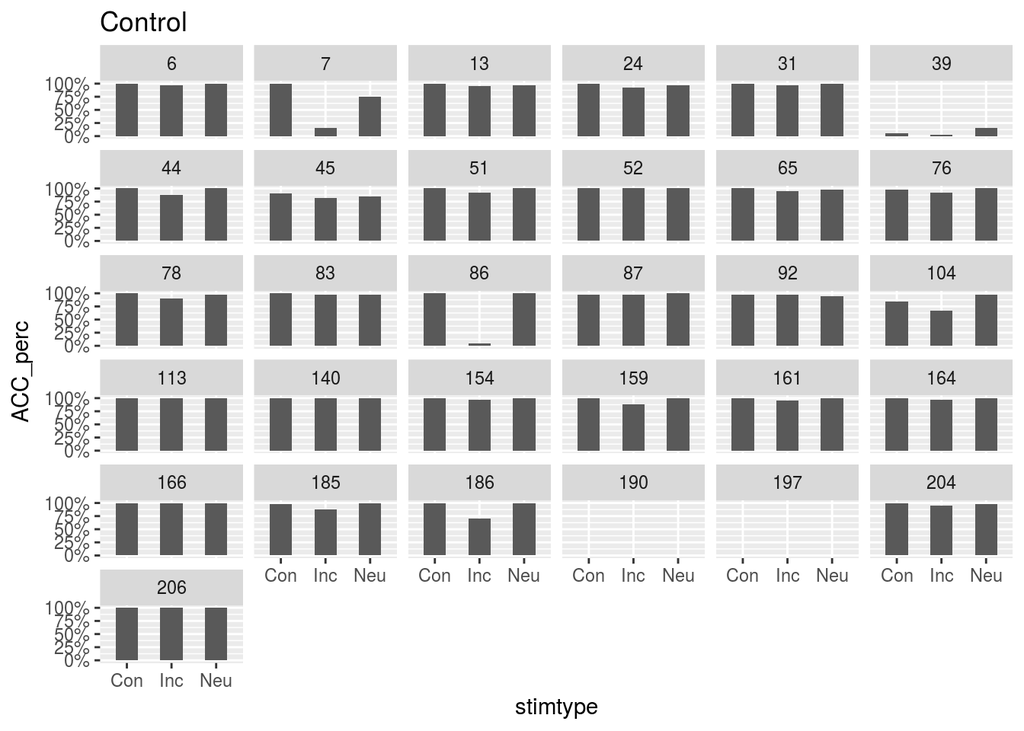

```r
#Control Condition Data
Flanker_data_pre_control <- subset(Flanker_data_pre, Condition=="Control")
#change binary data to a percent
Flanker_data_pre_control_percent <- ddply(Flanker_data_pre_control, .(stimtype, subject), summarize, ACC_perc = mean(ACC))

#Experimental Condition Data
Flanker_data_pre_experimental <- subset(Flanker_data_pre, Condition=="Experimental")
#change binary data to a percent
Flanker_data_pre_experimental_percent <- ddply(Flanker_data_pre_experimental, .(stimtype, subject), summarize, ACC_perc = mean(ACC))

ggplot(data = Flanker_data_pre_control_percent, aes( x = stimtype, y = ACC_perc)) + geom_bar(stat = "identity", width = 0.5) + facet_wrap(~subject) + scale_y_continuous(labels=percent) + scale_x_discrete(labels=c("Con","Inc","Neu")) + ggtitle("Control")
```

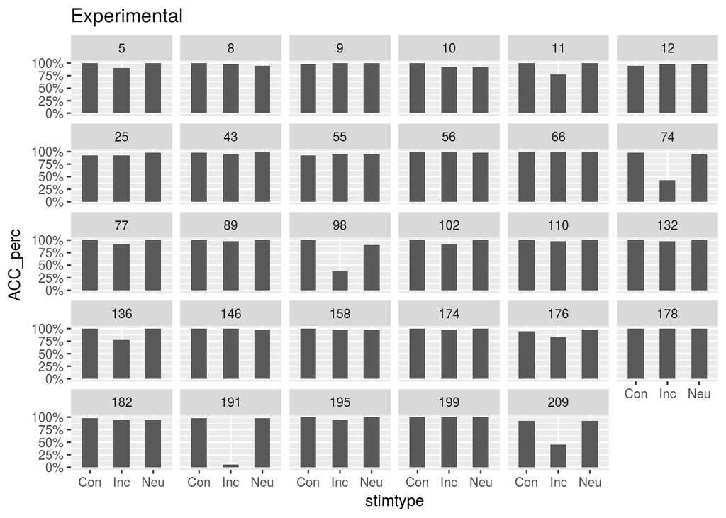

```r
ggplot(data = Flanker_data_pre_experimental_percent, aes( x = stimtype, y = ACC_perc)) + geom_bar(stat = "identity", width = 0.5) + facet_wrap(~subject) + scale_y_continuous(labels=percent) +  scale_x_discrete(labels=c("Con","Inc","Neu")) + ggtitle("Experimental")
```

**Conclusion**: Problem Subjects: sub190 sub197 sub39

Less Problematic subjects sub86 sub7 sub74 sub98 sub191

### Excluding subjects without/minimal data

```r
Flanker_data_pre <- subset(Flanker_data_pre, subject != 190 & subject != 197 & subject != 39)
summary(Flanker_data_pre)
```

```
##     subject     session           Condition         ACC
##  209    : 240   Pre:6962   Control     :3362   Min.   :0.0000
##  154    : 121              Experimental:3600   1st Qu.:1.0000
##  161    : 121                                  Median :1.0000
##  5      : 120                                  Mean   :0.9395
##  6      : 120                                  3rd Qu.:1.0000
##  7      : 120                                  Max.   :1.0000
##  (Other):6120
##        RT         stimtype
##  Min.   :   0.0   con:2320
##  1st Qu.: 607.2   inc:2320
##  Median : 694.0   neu:2322
##  Mean   : 728.1
##  3rd Qu.: 806.0
##  Max.   :1974.0
##
```

### Model Accuracy (Logit)

```r
Flanker_ACC_model<-glmer(ACC ~ Condition*stimtype + (1|subject), family=binomial, data=Flanker_data_pre, verbose=TRUE)
```

[output not shown]

```r
summary(Flanker_ACC_model)
```

```
## Generalized linear mixed model fit by maximum likelihood (Laplace
##   Approximation) [glmerMod]
##  Family: binomial  ( logit )
## Formula: ACC ~ Condition * stimtype + (1 | subject)
##    Data: Flanker_data_pre
##
##      AIC      BIC   logLik deviance df.resid
##   2168.1   2216.1  -1077.1   2154.1     6955
##
## Scaled residuals:
##      Min       1Q   Median       3Q      Max
## -22.3949   0.0522   0.0917   0.2216   1.6771
##
## Random effects:
##  Groups  Name        Variance Std.Dev.
##  subject (Intercept) 2.381    1.543
## Number of obs: 6962, groups:  subject, 57
##
## Fixed effects:
##                                   Estimate Std. Error z value Pr(>|z|)
## (Intercept)                         5.7010     0.4282  13.314   <2e-16 ***
## ConditionExperimental              -0.4395     0.5708  -0.770    0.441
## stimtypeinc                        -3.0353     0.3048  -9.957   <2e-16 ***
## stimtypeneu                        -0.6420     0.3453  -1.859    0.063 .
## ConditionExperimental:stimtypeinc   0.2823     0.3922   0.720    0.472
## ConditionExperimental:stimtypeneu   0.3302     0.4551   0.726    0.468
## ---
## Signif. codes:  0 '***' 0.001 '**' 0.01 '*' 0.05 '.' 0.1 ' ' 1
##
## Correlation of Fixed Effects:
##                        (Intr) CndtnE stmtypnc stimtypn
## CndtnExprmn            -0.739
## stimtypeinc            -0.655  0.488
## stimtypeneu            -0.514  0.385  0.719
## CndtnExprmntl:stmtypnc  0.506 -0.623 -0.776   -0.559
## CondtnExprmntl:stmtypn  0.390 -0.485 -0.546   -0.759
##                        CndtnExprmntl:stmtypnc
## CndtnExprmn
## stimtypeinc
## stimtypeneu
## CndtnExprmntl:stmtypnc
## CondtnExprmntl:stmtypn  0.704
```

## Flanker Reaction Time Analysis

### Format RT data

(subset for RTs when they are accurate, greater than 200ms, and less than 2000 ms) See how many observations are lost when we subset the data

```r
#all observations
print("All Data")
```

```
## [1] "All Data"
```

```r
All_data <- length(Flanker_data_pre$RT)
summary(Flanker_data_pre)
```

```
##     subject     session           Condition         ACC
##  209    : 240   Pre:6962   Control     :3362   Min.   :0.0000
##  154    : 121              Experimental:3600   1st Qu.:1.0000
##  161    : 121                                  Median :1.0000
##  5      : 120                                  Mean   :0.9395
##  6      : 120                                  3rd Qu.:1.0000
##  7      : 120                                  Max.   :1.0000
##  (Other):6120
##        RT         stimtype
##  Min.   :   0.0   con:2320
##  1st Qu.: 607.2   inc:2320
##  Median : 694.0   neu:2322
##  Mean   : 728.1
##  3rd Qu.: 806.0
##  Max.   :1974.0
##
```

```r
#remove innacurate responses
print("Removed innacurate trials (from all data dataframe)")
```

```
## [1] "Removed innacurate trials (from all data dataframe)"
```

```r
Flanker_data_pre_RT <- subset(Flanker_data_pre, ACC==1)
All_acc_data <- length(Flanker_data_pre_RT$RT)
summary(Flanker_data_pre_RT)
```

```
##     subject     session           Condition         ACC
##  209    : 184   Pre:6541   Control     :3176   Min.   :1
##  52     : 120              Experimental:3365   1st Qu.:1
##  66     : 120                                  Median :1
##  113    : 120                                  Mean   :1
##  140    : 120                                  3rd Qu.:1
##  154    : 120                                  Max.   :1
##  (Other):5757
##        RT         stimtype
##  Min.   : 282.0   con:2285
##  1st Qu.: 610.0   inc:1987
##  Median : 692.0   neu:2269
##  Mean   : 727.4
##  3rd Qu.: 798.0
##  Max.   :1957.0
##
```

```r
#remove short and long RTs
print("Removed slow and fast RTs")
```

```
## [1] "Removed slow and fast RTs"
```

```r
Flanker_data_pre_RT <- subset(Flanker_data_pre_RT, RT>200 & RT<2000)
filtered_data <- length(Flanker_data_pre_RT$RT)
summary(Flanker_data_pre_RT)
```

```
##     subject     session           Condition         ACC
##  209    : 184   Pre:6541   Control     :3176   Min.   :1
##  52     : 120              Experimental:3365   1st Qu.:1
##  66     : 120                                  Median :1
##  113    : 120                                  Mean   :1
##  140    : 120                                  3rd Qu.:1
##  154    : 120                                  Max.   :1
##  (Other):5757
##        RT         stimtype
##  Min.   : 282.0   con:2285
##  1st Qu.: 610.0   inc:1987
##  Median : 692.0   neu:2269
##  Mean   : 727.4
##  3rd Qu.: 798.0
##  Max.   :1957.0
##
```

```r
print("Percentage of Data Removed")
```

```
## [1] "Percentage of Data Removed"
```

```r
perc_data_rm <- (1 - (filtered_data/All_acc_data) ) * 100
perc_data_rm
```

```
## [1] 0
```

**Conclusion**: No Data removed from filtering. Good to go.

### Graph RT data

Note: just doing it by stimtype since subject data appears to be in good ranges

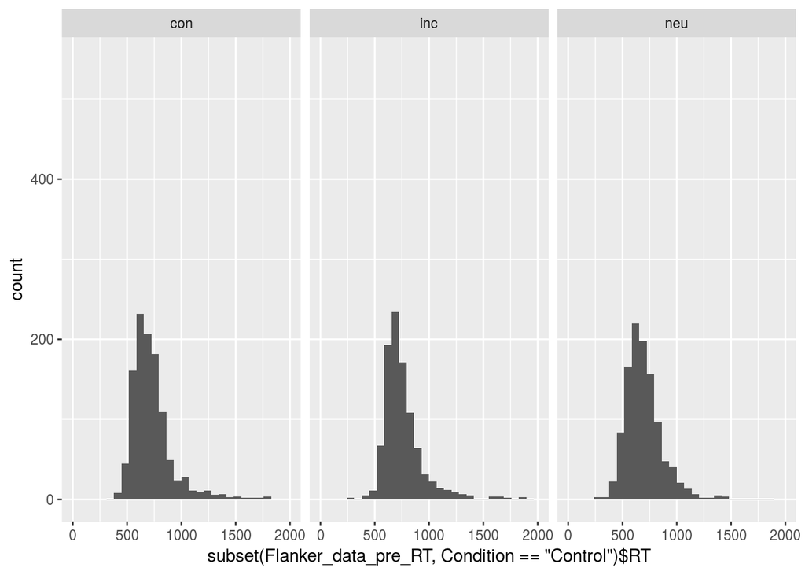

```r
#hist(subset(Flanker_data_pre_RT, Condition=="Control")$RT,ylim=c(0,1600))
#hist(subset(Flanker_data_pre_RT, Condition=="Experimental")$RT,ylim=c(0,1600))
ggplot(data = subset(Flanker_data_pre_RT, Condition=="Control"), aes(subset(Flanker_data_pre_RT, Condition=="Control")$RT)) + geom_histogram() + facet_wrap(~subset(Flanker_data_pre_RT, Condition=="Control")$stimtype) + scale_y_continuous(limits = c(0,550)) + scale_x_continuous(limits = c(0,2000))
```

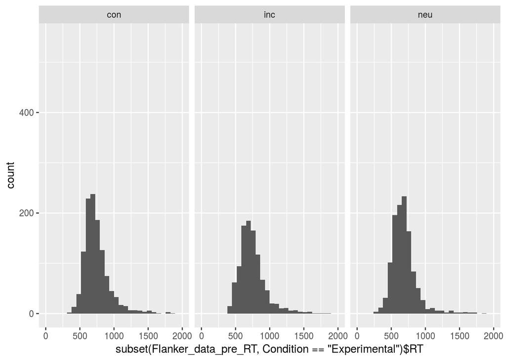

```r
ggplot(data = subset(Flanker_data_pre_RT, Condition=="Experimental"), aes(subset(Flanker_data_pre_RT, Condition=="Experimental")$RT)) + geom_histogram() + facet_wrap(~subset(Flanker_data_pre_RT, Condition=="Experimental")$stimtype) + scale_y_continuous(limits = c(0,550)) + scale_x_continuous(limits = c(0,2000))
```

**Conclusion**: data show a bit of skew, will transform to see if they look better

### Log Transform RT data

```r
Flanker_data_pre_RT$log_RT <- log(1/Flanker_data_pre_RT$RT)
```

### graph logged RT data

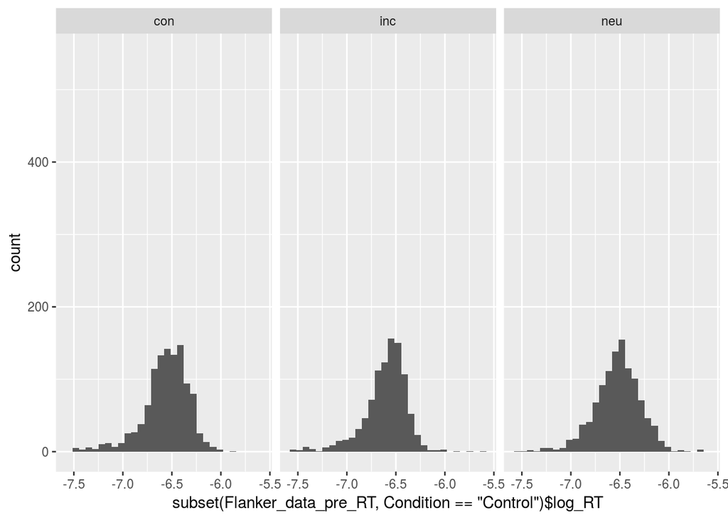

```r
#hist(subset(Flanker_data_pre_RT, Condition=="Control")$RT,ylim=c(0,1600))
#hist(subset(Flanker_data_pre_RT, Condition=="Experimental")$RT,ylim=c(0,1600))
ggplot(data = subset(Flanker_data_pre_RT, Condition=="Control"), aes(subset(Flanker_data_pre_RT, Condition=="Control")$log_RT)) + geom_histogram() + facet_wrap(~subset(Flanker_data_pre_RT, Condition=="Control")$stimtype) + scale_y_continuous(limits = c(0,550))
```

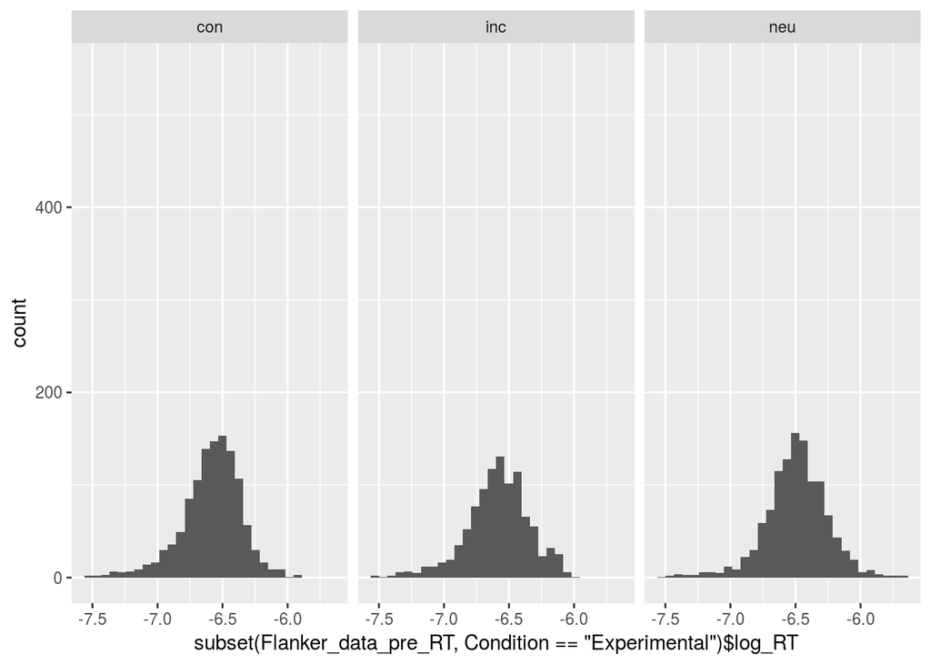

```r
ggplot(data = subset(Flanker_data_pre_RT, Condition=="Experimental"), aes(subset(Flanker_data_pre_RT, Condition=="Experimental")$log_RT)) + geom_histogram() + facet_wrap(~subset(Flanker_data_pre_RT, Condition=="Experimental")$stimtype) + scale_y_continuous(limits = c(0,550))
```

**Conclusion**: The transformed data look slightly better, I will run the model on both

### Model RT by Condition and stimtype

```r
Flanker_RT_model <- lmer(RT ~ Condition*stimtype + (1|subject), data = Flanker_data_pre_RT)
summary(Flanker_RT_model)
```

```
## Linear mixed model fit by REML t-tests use Satterthwaite approximations
##   to degrees of freedom [lmerMod]
## Formula: RT ~ Condition * stimtype + (1 | subject)
##    Data: Flanker_data_pre_RT
##
## REML criterion at convergence: 84124
##
## Scaled residuals:
##     Min      1Q  Median      3Q     Max
## -3.9993 -0.5602 -0.1437  0.3390  8.9483
##
## Random effects:
##  Groups   Name        Variance Std.Dev.
##  subject  (Intercept) 10003    100.0
##  Residual             21919    148.1
## Number of obs: 6541, groups:  subject, 57
##
## Fixed effects:
##                                     Estimate Std. Error         df t value
## (Intercept)                        686.16941   19.41844   59.00000  35.336
## ConditionExperimental               -0.21356   27.21581   59.00000  -0.008
## stimtypeinc                        173.54243    6.55586 6473.00000  26.471
## stimtypeneu                        -21.70962    6.31106 6468.00000  -3.440
## ConditionExperimental:stimtypeinc   -0.06235    9.15344 6472.00000  -0.007
## ConditionExperimental:stimtypeneu    9.35766    8.78236 6468.00000   1.066
##                                   Pr(>|t|)
## (Intercept)                        < 2e-16 ***
## ConditionExperimental             0.993766
## stimtypeinc                        < 2e-16 ***
## stimtypeneu                       0.000586 ***
## ConditionExperimental:stimtypeinc 0.994566
## ConditionExperimental:stimtypeneu 0.286687
## ---
## Signif. codes:  0 '***' 0.001 '**' 0.01 '*' 0.05 '.' 0.1 ' ' 1
##
## Correlation of Fixed Effects:
##                        (Intr) CndtnE stmtypnc stimtypn
## CndtnExprmn            -0.713
## stimtypeinc            -0.156  0.111
## stimtypeneu            -0.162  0.115  0.481
## CndtnExprmntl:stmtypnc  0.112 -0.155 -0.716   -0.344
## CondtnExprmntl:stmtypn  0.116 -0.161 -0.345   -0.719
##                        CndtnExprmntl:stmtypnc
## CndtnExprmn
## stimtypeinc
## stimtypeneu
## CndtnExprmntl:stmtypnc
## CondtnExprmntl:stmtypn  0.479
```

**Conclusions**: No main Condition effect or interactions (as expected), The incongruent condition is slower relative to the congruent condition (as expected). However, the neutral condition is faster than the congruent condition, which is unexpected.

### Model log RT by Condition and stimtype

```r
Flanker_log_RT_model <- lmer(log_RT ~ Condition*stimtype + (1|subject), data = Flanker_data_pre_RT)
summary(Flanker_log_RT_model)
```

```
## Linear mixed model fit by REML t-tests use Satterthwaite approximations
##   to degrees of freedom [lmerMod]
## Formula: log_RT ~ Condition * stimtype + (1 | subject)
##    Data: Flanker_data_pre_RT
##
## REML criterion at convergence: -4128
##
## Scaled residuals:
##     Min      1Q  Median      3Q     Max
## -6.9799 -0.4785  0.0980  0.6044  6.4000
##
## Random effects:
##  Groups   Name        Variance Std.Dev.
##  subject  (Intercept) 0.01725  0.1313
##  Residual             0.02986  0.1728
## Number of obs: 6541, groups:  subject, 57
##
## Fixed effects:
##                                     Estimate Std. Error         df
## (Intercept)                       -6.510e+00  2.536e-02  5.800e+01
## ConditionExperimental              4.454e-03  3.554e-02  5.800e+01
## stimtypeinc                       -2.152e-01  7.652e-03  6.484e+03
## stimtypeneu                        3.150e-02  7.366e-03  6.480e+03
## ConditionExperimental:stimtypeinc -7.656e-03  1.068e-02  6.484e+03
## ConditionExperimental:stimtypeneu -1.560e-02  1.025e-02  6.480e+03
##                                    t value Pr(>|t|)
## (Intercept)                       -256.733  < 2e-16 ***
## ConditionExperimental                0.125    0.901
## stimtypeinc                        -28.119  < 2e-16 ***
## stimtypeneu                          4.276 1.93e-05 ***
## ConditionExperimental:stimtypeinc   -0.717    0.474
## ConditionExperimental:stimtypeneu   -1.522    0.128
## ---
## Signif. codes:  0 '***' 0.001 '**' 0.01 '*' 0.05 '.' 0.1 ' ' 1
##
## Correlation of Fixed Effects:
##                        (Intr) CndtnE stmtypnc stimtypn
## CndtnExprmn            -0.713
## stimtypeinc            -0.139  0.099
## stimtypeneu            -0.145  0.103  0.481
## CndtnExprmntl:stmtypnc  0.100 -0.138 -0.716   -0.344
## CondtnExprmntl:stmtypn  0.104 -0.144 -0.345   -0.719
##                        CndtnExprmntl:stmtypnc
## CndtnExprmn
## stimtypeinc
## stimtypeneu
## CndtnExprmntl:stmtypnc
## CondtnExprmntl:stmtypn  0.479
```

**Conclusion**: Same story as the untransformed data.

## Conclusions

good: No overall Condition differences in RT and Accuracy

bad: 190,197, and 39 have almost no data. several other subjects have low accuracies. The neutral reaction times are faster than the congruent reaction times (unexpected)